# Will they make a purchase: Predictive Modeling for Revenue-generating Online Consumer Behaviors

STOR 320.02 Group 4

Dec. 5, 2019

# INTRODUCTION

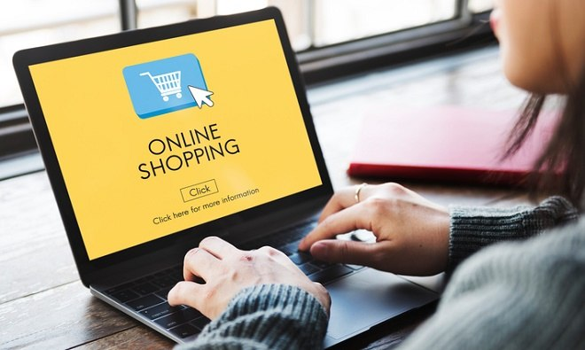

Online shopping has become a mainstay in the retail marketplace of consumer goods. When a person visits an e-commerce website, knowing whether or not they will make a purchase confers tremendous economic value. A 2018 study in the journal “Neural Computing and Applications” entitled, “Real-time prediction of online shoppers’ purchasing intention using multilayer perceptron and LSTM recurrent neural networks” employs a wealth of data logged from online consumer behavior at a large online bookstore’s website for just this purpose: to determine if a customer will make a purchase. The preprocessing data used in this study is known on Kaggle simply as “Online Shopper’s Intention,” and it contains 12,330 rows and 18 columns of data representing 10 numerical variables and 8 categorical variables. Of these, 17 predictor variables quantify certain kinds of website activity and classify consumers based on quasi-demographic information, ultimately to determine a single response variable, whether or not a transaction was made.

The first question our group chose to investigate in further detail is: Which variables are significant in predicting whether revenue is made or not? Our group found this question paramount to investigate because increasing revenue is a primary motivation when assuming a business mindset, but also plainly because using big data to understand customer purchasing behavior is the cardinal reason for which such datasets exist. As a secondary motivation, we were generally curious as to which customer behaviors actually do correlate with transactions, and moreover, we were curious to verify our intuitions. For instance, sensible contributors to transaction execution include whether or not a purchase occurred on a weekend, proximity of purchases to holidays, duration spent viewing a product page, and others. But in faithfully fulfilling essential business roles, we thought of the potential importance of certain operating systems, browsers, regions, traffic types, and intersections thereof in characterizing our market base and influencing marketing strategies, in this case as online booksellers. In these ways, the ability to identify extremely significant variables using data-driven techniques is a novel, insightful, and decisive way of maximizing revenue generation.

The second question our group chose to investigate in further detail is: Are returning visitors more likely to make revenue on the website? And as a corollary: Which variables are significant in predicting whether the visitor is new or returning? Our group found asking this question relevant less as a primary methodology and more as a supporting strategy. Although the data were obviously originally intended to predict transaction occurrence, treating Visitor Type as an output variable is a coherent and creative use of the dataset in learning more about behaviors and characteristics correlated with repeat customers. Traditionally, companies rely on a loyal customer base. Phrased a little differently, companies’ business plans prefer consistent and periodic use of the product or service sold, and repeat customers tend to fulfill this preference very well. Additionally and depending on the results, interpreting these variables as causative factors might inform storefront architects what not to do, or rather what could be done better in order to make a customer more likely to come back.

# DATA

The dataset named “Online Shopper’s Intention” was obtained from Kaggle, however it was originally sourced from the Center for Machine Learning and Intelligent Systems at the University of California in Irvine. This data repository currently maintains 488 datasets as a resource for machine learning investigation by professional researchers and students alike. The dataset in question specifically concerns web server log data from a large online bookstore. Before preprocessing, the dataset contained 12,330 observations of 10 numeric and 8 categorical variables. Each observation belonged to a different online user within a one-year period. After cleaning the data, a total of 12,283 observations remained. The cleaning process entailed removing the rows that contained insufficient data and mutating several names to numeric variables for easier management.

[output not shown]

The variables in the dataset include those such as month of purchase, browser type, and total duration of time spent on informational pages. After running tests to determine the most significant variables in predicting both revenue and visitor type, the focus was narrowed to only several of the initial eighteen variables. “Revenue,” is a binary categorical variable indicating whether or not a visit resulted in a transaction, is denoted either true or false. “VisitorType” is another categorical variable that classifies customers as either “returning,” “new,” or “other.” It was assumed that some entries were labeled “other” because the web server failed to recognize this information in the user cookie or elsewhere in their record. Including “other” as a potential visitor type was problematic because such entries inherently lack utility in determining significant predictors. However, only 1% of the total responses were classified this way, so they were decidedly omitted from the dataset, reducing the total number of observations to 12,198.

“Product Related Duration,” “Product Related,” “Administrative,” “Informational,” “Exit Rates,” “Bounce Rates,” “Page Values,” and “Special Day” were other significant numeric variables that used throughout the investigation. They were deemed significant based on the results section below. “Product Related Duration” measures the time in seconds that a user spends on a product related page. For clarification, this would be a page that contains the item desired for purchase. “Product Related” denotes the number of website pages visited by the user that fall under the product related category. The “Administrative” and “Informational” variables are similar to the “Product Related” variable; “Administrative” refers to the number of website pages visited related to account management, while “Informational” refers to the number of pages visited related to the website or contact information pages. “Exit Rates” gives the mean exit rate from the website page per user. This is calculated as the percentage of users who left the website from a particular page compared to all the views on that page. “Bounce Rates” is calculated by taking the percentage of visitors that enter a page and then immediately leave the site from that same page. “Page Values” is the average value, or price, of a page that the user visited before making a transaction. It was assumed that this variable is represented in dollars (USD), however this type of ambiguity was another identifiable issue in the dataset, and in more than one instance. Finally, “Special Day” represents the proximity of the website visit to a holiday, measured from 0 to 1 in increments of 0.2.

“Month,” “Weekend,” and “Operating Systems” were also significant categorical variables. “Month” shows the month of the year in which a website page was visited. In order to make this variable easier to negotiate, month names were coerced to simple integers (i.e. Jan=1, Feb=2, etc.). Because the dataset completely lacked entries for January and April, only the ten remaining months were used. “Weekend” is a binary categorical variable representing whether or not the website was visited on a weekend. Finally, “Operating Systems” is a categorical variable represented by integer numbers with eight levels numbered 1 through 8.

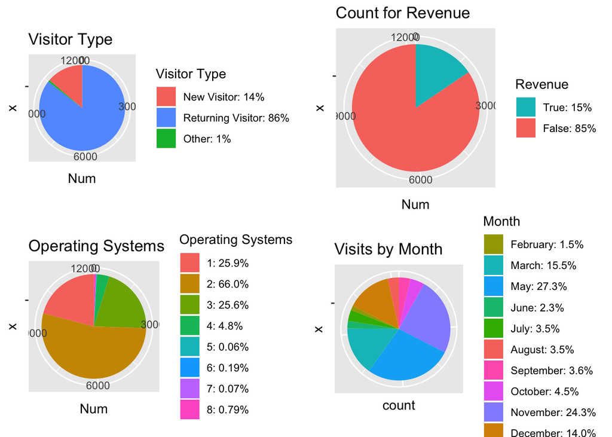

While the dataset provides a lot of information, it likewise poses many problems. A few problematic variables have already been mentioned. Other problems with the dataset include high correlations between many of the variables. Exit Rates are highly correlated with Bounce Rates, and Page Values are highly correlated with Product Related and Product Related Duration. The dataset is also unbalanced for many variables. For example, traffic type 12 in TrafficType has only 2 rows of data, which would create difficulty in building efficacious models using this traffic type. Additionally, some of the other variables’ responses are nonsensical. One such variable is browser; this variable has levels from 1 to 13, and there is no way to know which numbers correspond to Google, Safari, or Firefox, etc.. This is a common theme among the variables “OperatingSystems,” “Region” (geographic region from which the site was visited), “TrafficType” (where the site was visited from, e.g. text message or banner ad), as well as “Browser.” Also, in the variable “Special Day,” there is no reference list of which days are considered holidays. “Special Day” is problematic furthermore because only special days in February and May were identified. However, it was hypothesized that some of this information was intentionally omitted for proprietary reasons, preserving a proof-of-concept. Moreover, the study was conducted in Turkey and the authors were not responsive when contacted. Nevertheless, it is nearly certain that some entity possesses this information, and thus the research performed here would still be hypothetically pertinent in a business setting.

# RESULTS

#### Question 1: Which variables are significant in predicting whether revenue is made or not?

To investigate the important variables in predicting the successfulness of the transaction, we tried to do forward and backward selection to build a logistic regression model and used Elastic Net to build an alternative one. Before building models, we first split the data into train and test datasets.

The coefficients of Model3 tell us that visitors with high exit rates, visitors who spend less time reading product related pages, visitors with low page values, and returning visitors are less likely to purchase on the website. Certain months like February, December, March, and May are not a good time for visitors to make a purchase online even though the number of visits might be large during these months. The biggest problem with all the models is that the sensitivity is much lower than specificity. All the models had a higher accuracy for predicting no revenue than predicting a revenue. This is because the dataset is biased towards Revenue equals “0” with about 85% of the datasets making no revenue. Our model is not significantly effective in predicting whether the revenue is made or not, but it did help to make a better prediction than guessing, as its accuracy is slightly higher than 85%.

| Summary of Model 3 | Coefficient | p-value |
| --- | --- | --- |
| Intercept | -1.6204059 | 0.00000 |
| ProductRelated_Duration | 0.0000488 | 0.07720 |
| ProductRelated | 0.0023563 | 0.06418 |
| ExitRates | -17.8707143 | 0.00000 |
| PageValues | 0.0820314 | 0.00000 |
| VisitorTypeOther | -0.7061860 | 0.22279 |
| VisitorTypeReturning_Visitor | -0.2876828 | 0.00500 |
| MonthDec | -0.6522849 | 0.00207 |
| MonthFeb | -2.4432983 | 0.01901 |
| MonthJul | -0.0471178 | 0.85581 |
| MonthJune | -0.1711798 | 0.59038 |
| MonthMar | -0.5057956 | 0.01616 |
| MonthMay | -0.6135096 | 0.00183 |

Finally, we were wondering whether using more advanced techniques would further improve our model’s predictive performance. We decided to try machine learning techniques. First, we ran an initial Random Forest model with 100 trees. We looked at the error rates associated with the different number of trees. We found that there was no significant improvement in the error rate when the model had more than 20 trees. Therefore, we decided to just use 20 trees as the ntree parameter. Next, we tuned the number of variables randomly sampled as candidates at each split. The out-of-bag error was shown to continuously increasing, with the lowest out-of-bag error at 1. We thought just using this would be very biased, so we decided to go with the default value (sqrt(6)). Combining these, we used ntree=20 and mtry=sqrt(6) as the hyperparameters in the final Random Forest model. The model obtained an accuracy of 90.39% and a sensitivity of 61.5%, which was the best we had so far. The specificity, 95.56%, was not as good as other models. However, we considered this Random Forest model the best-performing model among all.

| Summary of Model Selection | Accuracy | Specificity | Sensitivity |
| --- | --- | --- | --- |
| Model1 | 0.8765000 | 0.9879000 | 0.2500000 |
| Model2 | 0.8823038 | 0.9809586 | 0.3339416 |
| Model3 | 0.8863000 | 0.9732000 | 0.3975000 |
| Random Forest Model | 0.9039000 | 0.9556000 | 0.6150000 |

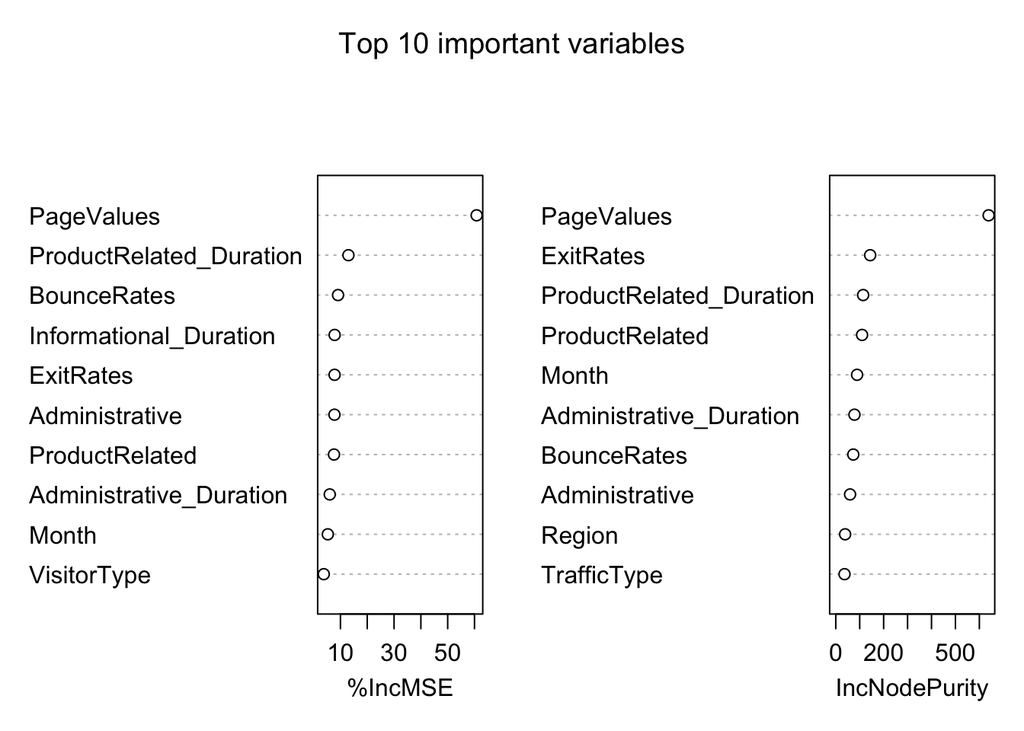

#### Question 2: Are returning visitors more likely to make revenue on the website? Which variables are significant in predicting whether the visitor is new or returning?

We knew from our first question that VisitorType was significant in predicting revenue. Therefore, we wanted to further investigate how Visitor Type was related to Revenue. First of all, we did not want to look at the “Other” visitor type while we analyzed the relationship between Visitor Type and Revenue, so we took it out. This left only two levels: “New_Visitor” and “Returning_Visitor.” We then looked at the proportion of successful transactions among new visitors and returning visitors. It seemed that returning visitors had a lower proportion of successful transactions in the dataset.

| VisitorType | Revenue | Number_Successful_Transaction | Proportion_Successful_Transaction |
| --- | --- | --- | --- |
| New_Visitor | TRUE | 422 | 0.2491145 |
| Returning_Visitor | TRUE | 1470 | 0.1399467 |

We then built a logistic model using only Visitor Type to predict Revenue, and it showed that Visitor Type in the model had a very significant p-value of 0.0000000000000002 and a negative coefficient of -0.109168. It gives us some evidence that returning visitors might be less likely to make a purchase on the website. Knowing this information, we wanted to see if we could predict whether a user was a returning visitor or a new visitor based on other variables we had.

| Summary of Model with VisitorType Predicting on Revenue | Coefficient | p-value |
| --- | --- | --- |
| Intercept | 0.249115 | 0.0000000000000002 |
| VisitorType: Returning_visitor | -0.109168 | 0.0000000000000002 |

To investigate the important variables in predicting the VisitorType, we split the data into train and test. Then, we turned VisitorType into a binary variable with “1” indicating a new visitor and “0” indicating a returning visitor. In other words, our model was used to predict whether the visitor is a new visitor or not (returning visitor). We used forward selection and backward selection to look at the Cp, BIC and adjusted R^2 of models with a different number of variables. Looking at where the rates of change of Cp, BIC, and adjusted R^2 versus the number of variables slowed down, we identified 7 variables to include in our model. Then we built a logistic regression model using these 7 variables and named the model Visitor_Model1. This model has a very low accuracy of about 13.47% and an extremely low sensitivity of 1.1353%, so we tried the all-subsets method to look at all combinations of variables to predict whether the visitor was a new visitor or not. The model with the lowest BIC contained 11 variables and had an accuracy of 13.28%. The specificity was 92.2290%, and the sensitivity was 1.1038%. The model did very poorly in predicting whether the visitor is a new visitor or returning visitor. We found at this point that building model to predict on VisitorType is not very effective because the dataset is very biased towards “Returning_Visitor” and the variables we have might not be appropriate to predict the Visitor Type.

| Summary of Model Selection | Accuracy | Specificity | Sensitivity |
| --- | --- | --- | --- |
| Visitor_Model1 | 0.1347 | 0.93456 | 0.011353 |
| Visitor_Model2 | 0.1328 | 0.92229 | 0.011038 |

# CONCLUSION

One question investigated was: Which variables are significant in predicting whether revenue is made or not? Using techniques learned in class, Model3 was built with 6 variables: Product Related Duration, Product Related, Exit Rates, Page Values, Visitor Type, and Month. This model had an accuracy of 88.6%; while not superb, this is much better than purely guessing. A machine learning technique was also attempted, and the final model had an ntree=20 and mtry=sqrt(6) as the hyperparameters, achieving an accuracy of 90.39%. As aforementioned, the data were rather unbalanced, with 85% of the observations having FALSE as the Revenue class label. This was the primary reason why the models used had relatively low sensitivity and poor predictive performance. To improve this in the future, a larger and more balanced dataset would be required. Reducing the FALSE class size to match the TRUE class size may also help; this would reduce the data size to approximately 4,000 observations. Because the modeling was mainly classification-based, many other more powerful classification methods could have been potentially used, such as KNN, Decision Tree, and Boosting, among others. Given more time, these methods would have been more feasibly explored.